$$~$$

**Sapienza University of Rome**

*Statistical Methods in Data Science & Laboratory II*

2023/2024

Luca Mazzucco: 1997610

$$~$$

**Bayesian Mushroom Classifier 🍄🔍**

$$~$$

### Loading the Data:

The dataset chosen is the **Mushroom dataset**, from [Kaggle](https://www.kaggle.com/datasets/prishasawhney/mushroom-dataset). It provides attributes and physical characteristics of 54035 mushrooms.

The task proposed is a **binary classification problem**, aiming to determine whether a mushroom is `edible` or `poisonous`.

The dataset is loaded through Kaggle API and first rows are displayed.

```r
# from Kaggle → settings → API → download 'New Token' in working directory

data <- read_csv("mushroom-dataset.zip")
```

| cap-diameter | cap-shape | gill-attachment | gill-color | stem-height | stem-width | stem-color | season | class |
| --- | --- | --- | --- | --- | --- | --- | --- | --- |
| 1372 | 2 | 2 | 10 | 3.807467 | 1545 | 11 | 1.8042727 | 1 |
| 1461 | 2 | 2 | 10 | 3.807467 | 1557 | 11 | 1.8042727 | 1 |
| 1371 | 2 | 2 | 10 | 3.612496 | 1566 | 11 | 1.8042727 | 1 |
| 1261 | 6 | 2 | 10 | 3.787572 | 1566 | 11 | 1.8042727 | 1 |
| 1305 | 6 | 2 | 10 | 3.711971 | 1464 | 11 | 0.9431946 | 1 |

```
## Number of NaN values: 0
```

```
## Number of duplicates: 303 -> removed! 53732
```

```
## Dataset size:  53732 x 9
```

Here a brief description of each feature:

```
## Features:
```

```
## [1] "cap-diameter"    "cap-shape"       "gill-attachment" "gill-color"
## [5] "stem-height"     "stem-width"      "stem-color"      "season"
## [9] "class"
```

- `cap-diameter` → diameter of the mushroom cap (continuous)
- `cap-shape` → shape of the mushroom cap
- `gill-attachment` → gill attach to the stem of the mushroom
- `gill-color` → color of the gills of the mushroom
- `stem-height` → height of the mushroom stem (continuous)
- `stem-width` → width of the mushroom stem (continuous)
- `stem-color` → color of the stem of the mushroom
- `season` → season of the mushroom

**EDA & Visualization**

Inspecting the distribution of the dataset’s features, plots for the **categorical variables**:

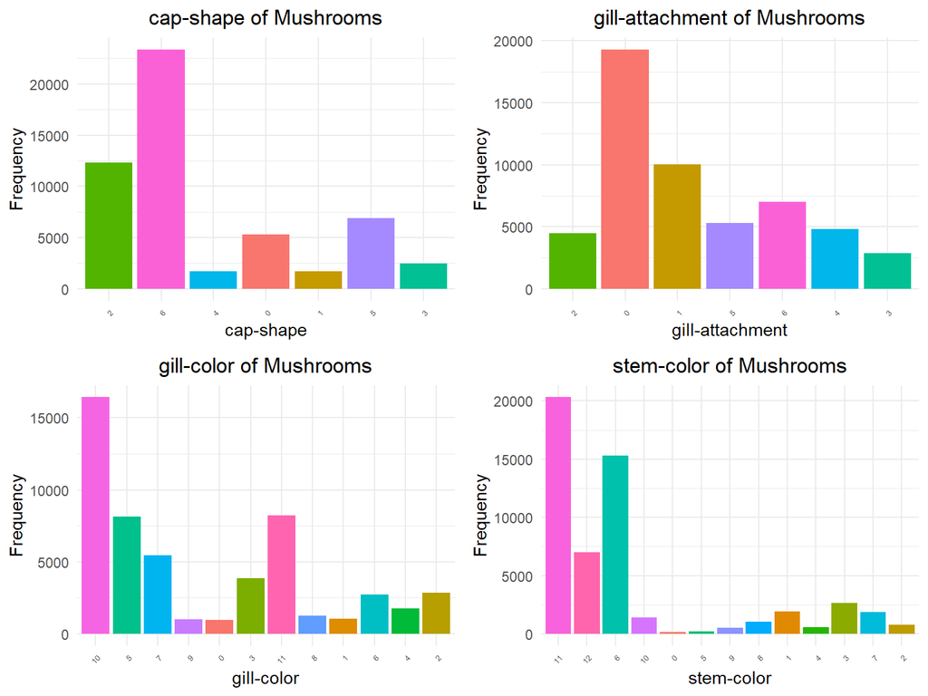

Below are visualized the *density distributions* for **continuous variables** using the `highcharter` library.  
The variables plotted include **cap-diameter**, **stem-height**, and **stem-width**.  
For each of these variables, density plots are shown to compare the distributions between two classes: Class 0 (Edible) and Class 1 (Poisonous), with green and red lines respectively.

[interactive chart not shown]

**Correlations** between the features measured considering the Pearson coefficient:

[interactive chart not shown]

Let’s see the distribution of the target variable across the dataset.

The classes appear reasonably balanced, with `Edible` and `Poisonous` represented quite fairly.

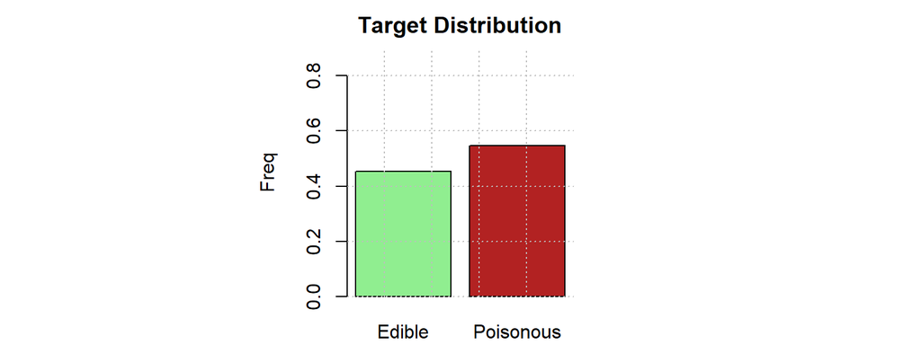

### Frequentist Baseline:

Splitting data in Train (70%) and Test (30%) sets, the latter of which will be used to evaluate the performance of the models.

```
## train_data: 37612 9
```

```
##  test_data: 16120 9
```

**Frequentist approach** → *Logistic Regression* with *glm*

```r
model <- glm(class ~ ., data = train_data, family = binomial)

predictions <- predict(model, newdata = test_data, type = "response")
```

A logistic regression approach is initially chosen to assess the performance of standard machine learning methods.

The model yielded poor results, achieving an accuracy of 63%.

The aim is to examine whether the Bayesian analysis can improve upon this outcomes or, at the very least, confirm them.

```
## Accuracy: 0.6341
```

```
## Precision: 0.7044
```

```
## Recall: 0.6521
```

```
## F1 Score: 0.6772
```

Below are the coefficients obtained from the logistic regression model and their p-values:

```
##                        Estimate   Std. Error    z value      Pr(>|z|)
## (Intercept)        1.6719678205 5.611238e-02  29.796771 4.301673e-195
## `cap-diameter`    -0.0003902568 5.578779e-05  -6.995380  2.645407e-12
## `cap-shape`       -0.0905484347 5.256420e-03 -17.226254  1.687306e-66
## `gill-attachment`  0.0119229069 5.119822e-03   2.328774  1.987107e-02
## `gill-color`      -0.0082895759 3.566695e-03  -2.324162  2.011683e-02
## `stem-height`      0.7343691096 1.900925e-02  38.632189  0.000000e+00
## `stem-width`      -0.0003176303 2.590100e-05 -12.263247  1.426665e-34
## `stem-color`      -0.0691048948 3.482045e-03 -19.846067  1.191728e-87
## season            -0.4901594094 3.734476e-02 -13.125252  2.359974e-39
```

**S-shaped Curve:**

Here are presented the predictions – output probabilities from the logistic regression model – for each observation in the Test set.

Plotting the probabilities in ascending order → **Sigmoid function** with typical “S-shape”.

Provides a visual representation of how confident the model is in its predictions:

In this case the flatter curve indicates model uncertainty, while a sharp “S” curve suggests significant distinction between the two classes.

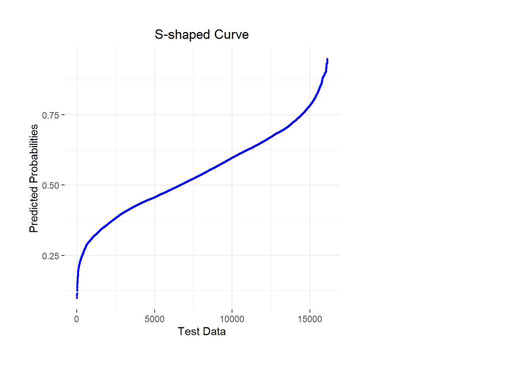

### JAGS - Just Another Gibbs Sampler

#### Bayesian Logistic Regression Model:

The target variable `class`, representing the binary response $Y_i$, is assumed to follow a Bernoulli distribution with probability of success $p_i$.

$$Y_i|p_i \sim \text{Bernoulli}(p_i), \ \
\ \ \ i=1,..., n$$

The logistic regression model states that the **logit** of the probability $p_i$ - the natural logarithm of the odds of success - $~$ is expressed as a linear combination of the predictor variables $x_i$.

So, the **logistic regression model** can be written as:

$$\text{logit}(p_i) =
\log\left(\frac{p_i}{1 - p_i}\right) = \beta_0 + \beta_1 x_{i1} +
\beta_2 x_{i2} + \cdots + \beta_k x_{ik}$$

where:

- $p_i$ is the probability of success for observation $i$,
- $\beta_0$ is the intercept,
- $\beta_1, \beta_2, \ldots, \beta_k$ are the coefficients for the predictor variables,
- $x_{i1}, x_{i2}, \ldots, x_{ik}$ are the predictor variables for observation $i$,
- $k$ is the total number of features.

Note that the probability of success $p_i$ can be expressed as follows.  
This formulation also highlights that the **logit function** ensures the probability $p_i$ lie within the interval $[0,1]$.

$$p_i = \frac{\exp\left(\beta_0 +
\sum_{j=1}^k \beta_j x_{ij}\right)}{1 + \exp\left(\beta_0 +
\sum_{j=1}^k \beta_j x_{ij}\right)} = \frac{1}{1+\exp\left(-(\beta_0 +
\sum_{j=1}^k \beta_j x_{ij})\right)}$$

The model is implemented using **RJags**.  
Preparing the data in the format required by `RJags` and initializing the **model parameters**:

```r
library(R2jags)

# --- Run JAGS --- #

data.jags <- list("y" = as.vector(train_data$class),
                  "N" = nrow(train_data),
                  "x1" = as.vector(train_data$"cap-diameter"),
                  "x2" = as.vector(train_data$"cap-shape"),
                  "x3" = as.vector(train_data$"gill-attachment"),
                  "x4" = as.vector(train_data$"gill-color"),
                  "x5" = as.vector(train_data$"stem-height"),
                  "x6" = as.vector(train_data$"stem-width"),
                  "x7" = as.vector(train_data$"stem-color"),
                  "x8" = as.vector(train_data$"season"))

params <- c("beta0", "beta1", "beta2", "beta3",
            "beta4", "beta5", "beta6", "beta7", "beta8")

inits <- function() {list( beta0 = 0, beta1 = 0, beta2 = 0, beta3 = 0,
                           beta4 = 0, beta5 = 0, beta6 = 0, beta7 = 0, beta8 = 0) }
```

**Model Definition**:

Choosing a prior on the vector of the regression coefficients:$\beta = (\beta_0, \beta_1, \beta_2, \beta_3, \beta_4, \beta_5, \beta_6, \beta_7, \beta_8)$

The **beta prior parameters** are supposed to be distributed as Normal distribution:

```r
# JAGS Model Definition

jags_model <- "
model {
  # Likelihood
  for (i in 1:N) {
    y[i] ~ dbern(p[i])         # Binary outcome follows Bernoulli distribution
    logit(p[i]) <- beta0 +     # Logistic regression model
                   beta1 * x1[i] +
                   beta2 * x2[i] +
                   beta3 * x3[i] +
                   beta4 * x4[i] +
                   beta5 * x5[i] +
                   beta6 * x6[i] +
                   beta7 * x7[i] +
                   beta8 * x8[i]   }

  # Priors for regression coefficients

  beta0 ~ dnorm(0,  0.001)        # Intercept
  beta1 ~ dnorm(0,  0.001)        # Coefficients for features
  beta2 ~ dnorm(0,  0.001)
  beta3 ~ dnorm(0,  0.001)
  beta4 ~ dnorm(0,  0.001)
  beta5 ~ dnorm(0,  0.001)
  beta6 ~ dnorm(0,  0.001)
  beta7 ~ dnorm(0,  0.001)
  beta8 ~ dnorm(0,  0.001)  }"

writeLines(jags_model, "model_one.txt")  # Save the JAGS model in a .txt file
```

```r
myfirstjags <- jags(data=data.jags,              # data
                    model.file="model_one.txt",  # model
                    parameters.to.save=params,   # traking
                    inits=inits,
                    n.chains=3,
                    n.iter=1000,
                    n.burnin=100)
```

```
## module glm loaded
```

```
## Inference for Bugs model at "model_one.txt", fit using jags,
##  3 chains, each with 1000 iterations (first 100 discarded)
##  n.sims = 2700 iterations saved
##            mu.vect sd.vect      2.5%       25%       50%       75%     97.5%
## beta0        1.674   0.057     1.562     1.637     1.675     1.713     1.784
## beta1        0.000   0.000     0.000     0.000     0.000     0.000     0.000
## beta2       -0.091   0.005    -0.101    -0.094    -0.091    -0.087    -0.080
## beta3        0.012   0.005     0.002     0.009     0.012     0.015     0.022
## beta4       -0.008   0.004    -0.016    -0.011    -0.008    -0.006    -0.001
## beta5        0.734   0.020     0.696     0.722     0.734     0.748     0.771
## beta6        0.000   0.000     0.000     0.000     0.000     0.000     0.000
## beta7       -0.069   0.004    -0.076    -0.072    -0.069    -0.067    -0.062
## beta8       -0.492   0.036    -0.560    -0.517    -0.492    -0.467    -0.423
## deviance 47992.636   7.789 47986.064 47989.230 47991.748 47994.797 48002.787
##           Rhat n.eff
## beta0    1.001  2700
## beta1    1.000     1
## beta2    1.001  2100
## beta3    1.002  1600
## beta4    1.001  2700
## beta5    1.001  2700
## beta6    1.000     1
## beta7    1.001  2700
## beta8    1.002  1600
## deviance 1.001  2700
##
## For each parameter, n.eff is a crude measure of effective sample size,
## and Rhat is the potential scale reduction factor (at convergence, Rhat=1).
##
## DIC info (using the rule, pD = var(deviance)/2)
## pD = 30.3 and DIC = 48023.0
## DIC is an estimate of expected predictive error (lower deviance is better).
```

The table summarizes the output for the JAGS model.

In particular:

- *mu.vect* shows the average of the posterior distribution for each of the parameters.
- *sd.vect* is standard deviation of the posterior, representing the uncertainty in the parameter estimate.
- *Rhat* measures the convergence of the chains. For all parameters, Rhat is close to 1, meaning the chains have converged well.
- *n.eff* is the effective number of samples to achieve the convergence → stationary region.

Below is a comparison of the estimated values of the Coefficients for the **Frequentist model** and the **Bayesian model** which are essentially completely similar to each other:

```
##                    jags_coef   freq_coef
## (Intercept)          1.674146    1.671968
## `cap-diameter`      -0.000388   -0.000390
## `cap-shape`         -0.090743   -0.090548
## `gill-attachment`    0.011893    0.011923
## `gill-color`        -0.008374   -0.008290
## `stem-height`        0.734198    0.734369
## `stem-width`        -0.000318   -0.000318
## `stem-color`        -0.069094   -0.069105
## season              -0.491745   -0.490159
```

#### Predictions: Posterior Predictive

Computing predictive density for new observations $(\tilde{y}_i)$ :

$$f(\tilde{y}_i = \tilde{y}_i \mid y) =
\int \pi(\beta \mid y) \ \ f(\tilde{y}_i, \beta) \ \ d\beta$$

where:

- $\pi(\beta \mid y)$: is the **posterior density** of the regression coefficients $(\beta = (\beta_0, \beta_1,\dots,)$, given observed data $y$.
- $f(\tilde{y}_i, \beta)$: is the **joint density** of the future observation $(\tilde{y}_i)$ and the regression coefficients $\beta$

```r
beta_est <- list("beta0" = myfirstjags$BUGSoutput$summary["beta0", "mean"],
               "beta1" = myfirstjags$BUGSoutput$summary["beta1", "mean"],
               "beta2" = myfirstjags$BUGSoutput$summary["beta2", "mean"],
               "beta3" = myfirstjags$BUGSoutput$summary["beta3", "mean"],
               "beta4" = myfirstjags$BUGSoutput$summary["beta4", "mean"],
               "beta5" = myfirstjags$BUGSoutput$summary["beta5", "mean"],
               "beta6" = myfirstjags$BUGSoutput$summary["beta6", "mean"],
               "beta7" = myfirstjags$BUGSoutput$summary["beta7", "mean"],
               "beta8" = myfirstjags$BUGSoutput$summary["beta8", "mean"])

test_data$output_predictive <- apply(test_data, 1, function(x){

 logit<-beta_est$beta0 + beta_est$beta1 * x["cap-diameter"] +
                         beta_est$beta2 * x["cap-shape"] +
                         beta_est$beta3 * x["gill-attachment"] +
                         beta_est$beta4 * x["gill-color"] +
                         beta_est$beta5 * x["stem-height"] +
                         beta_est$beta6 * x["stem-width"] +
                         beta_est$beta7 * x["stem-color"] +
                         beta_est$beta8 * x["season"]

sigmoid_samples <- (1 / (1 + exp(-logit)))
y_pred <- rbinom(n = 1000, size = 1, prob = sigmoid_samples)

predicted <- unique(y_pred)
predicted <- predicted[which.max(tabulate(match(y_pred, predicted)))]

return(predicted) })

accuracy <- mean(test_data$output_predictive == test_data$class)
cat(paste("Accuracy:", round(accuracy, 4)))
```

```
## Accuracy: 0.6347
```

[interactive chart not shown]

#### Credible Intervals: Evaluation of feature relevance through Posterior Distributions:

In this section credible intervals at 95% level are used to assess the **relevance of features** by examining the posterior distributions of the $\beta$ coefficients.

For each parameter, the interval is computed, and its inclusion or exclusion of zero is evaluated to determine whether the feature has a meaningful contribution to the model.

- If zero lies within the interval → the feature may be less relevant.
- If zero is excluded → the feature likely influences the response variable.

More formally:

$$H_0: 0 \notin CI_{\beta_i}(0.95) \quad
\text{vs} \quad H_1: 0 \in CI_{\beta_i}(0.95)$$

The **Null Hypothesis**: states that the the feature of interest is relevant (zero is excluded from the 95% credible interval)

The **Alternative Hypothesis**: asserts that the feature of interest is not relevant (zero is included in the 95% credible interval)

```r
create_density_plot <- function(data, parameter_name) {

  df <- data.frame(value = data[[parameter_name]])
  xlim <- c(min(df), max(df))

  intervals <- round(cbind(quantile(df$value, 0.025, na.rm = TRUE),
                            quantile(df$value, 0.975, na.rm = TRUE)), 6)

  inclusion_message <- if ((0 > intervals[1]) & (0 < intervals[2])) {"zero is included"}
                       else {"zero is excluded"}

  m <- paste()
  cat("Parameter:", parameter_name, "->", inclusion_message, "\n")
  cat(" - Lower Bound:", intervals[1], "\n")
  cat(" - Upper Bound:", intervals[2], "\n\n")

  ggplot(df, aes(x = value)) +
    geom_density(fill = "purple", alpha = 0.5) +
    labs(title = paste("Posterior Density of", parameter_name), x =  parameter_name, y = NULL) +
    theme_minimal() +
    theme(plot.title = element_text(hjust = 0.5, size=10))+
    geom_vline(xintercept = mean(df$value, na.rm = TRUE), linetype = "dotted", color = "black") +
    geom_vline(xintercept = quantile(df$value, 0.025, na.rm = TRUE), linetype = "dotted", color = "red") +
    geom_vline(xintercept = quantile(df$value, 0.975, na.rm = TRUE), linetype = "dotted", color = "red") +
    coord_cartesian(xlim = xlim, expand = FALSE) }

density_plots <- lapply(params, create_density_plot, data = myfirstjags$BUGSoutput$sims.list)
```

```
## Parameter: beta0 -> zero is excluded
##  - Lower Bound: 1.562441
##  - Upper Bound: 1.784126
##
## Parameter: beta1 -> zero is excluded
##  - Lower Bound: -0.000496
##  - Upper Bound: -0.000282
##
## Parameter: beta2 -> zero is excluded
##  - Lower Bound: -0.101484
##  - Upper Bound: -0.080353
##
## Parameter: beta3 -> zero is excluded
##  - Lower Bound: 0.00209
##  - Upper Bound: 0.021889
##
## Parameter: beta4 -> zero is excluded
##  - Lower Bound: -0.015552
##  - Upper Bound: -0.001148
##
## Parameter: beta5 -> zero is excluded
##  - Lower Bound: 0.696104
##  - Upper Bound: 0.770736
##
## Parameter: beta6 -> zero is excluded
##  - Lower Bound: -0.000369
##  - Upper Bound: -0.000264
##
## Parameter: beta7 -> zero is excluded
##  - Lower Bound: -0.075913
##  - Upper Bound: -0.061845
##
## Parameter: beta8 -> zero is excluded
##  - Lower Bound: -0.560086
##  - Upper Bound: -0.422958
```

Density plots visualize **posterior distributions**, highlighting the credible intervals and means.

Since zero is not contained in any of the credible intervals, it suggests that all the model parameters are statistically significant (all model features seem to have a significant effect on the response variable)

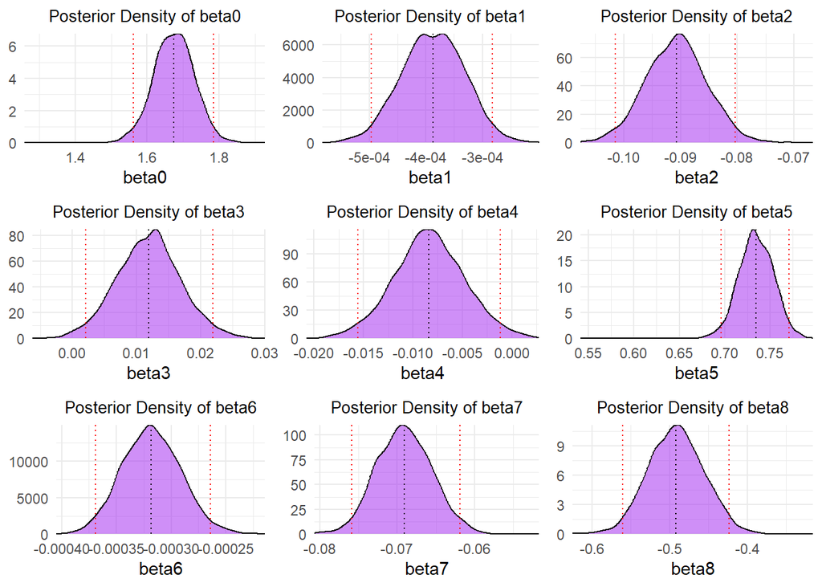

#### Convergence of MCMC:

Here, are shown the univariate **traceplots** for the simulations of each parameter.  
Traceplots are an essential tool in Bayesian modeling as they help assess the convergence of Markov Chains providing a visualization to check whether the chains have stabilized after the burn-in $(=100)$ period.

From the plots below, it is evident that all three chains are stable and do not exhibit any discernible trends or drift. Additionally, the chains converge to the same region of the parameter space, indicating that the **posterior distribution** is being sampled correctly and that the model is likely converging as expected.

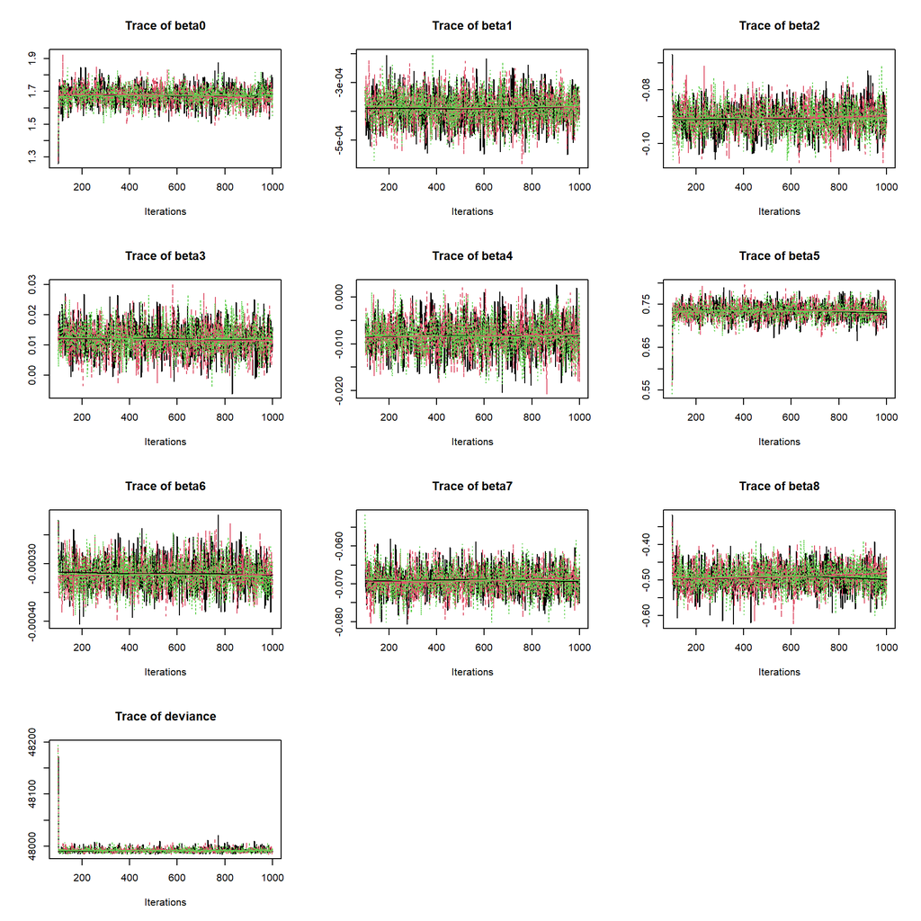

```r
library(coda)

 model_1=as.mcmc(myfirstjags)
 par(mfrow=c(4,3))
traceplot(model_1)
```

### Alternative Model:

This approach aims to evaluate whether a **simpler model**, with fewer predictors, performs comparably to the original, more complex model. By focusing on the most relevant features, this model tests whether reduced complexity can achieve similar predictive results.

```r
data.jags <- list("y" = as.vector(train_data$class),
                  "N" = nrow(train_data),
                  "x2" = as.vector(train_data$"cap-shape"),
                  "x5" = as.vector(train_data$"stem-height"),
                  "x7" = as.vector(train_data$"stem-color"),
                  "x8" = as.vector(train_data$"season") )

                  # "x1" = as.vector(train_data$"cap-diameter"),
                  # "x3" = as.vector(train_data$"gill-attachment"),
                  # "x4" = as.vector(train_data$"gill-color"),
                  # "x6" = as.vector(train_data$"stem-width"),

params <- c("beta0", "beta2", "beta5","beta7", "beta8")

inits <- function() {list( beta0 = 0, beta2 = 0, beta5 = 0, beta7=0, beta8 = 0) }


jags_model <- "
model {
  # Likelihood
  for (i in 1:N) {
    y[i] ~ dbern(p[i])         # Binary outcome follows Bernoulli distribution
    logit(p[i]) <- beta0 +     # Logistic regression model
                   beta2 * x2[i] +
                   beta5 * x5[i] +
                   beta7 * x7[i] +
                   beta8 * x8[i]   }

  # Priors for regression coefficients

  beta0 ~ dnorm(0,  0.001)        # Intercept
  beta2 ~ dnorm(0,  0.001)        # Coefficients for features
  beta5 ~ dnorm(0,  0.001)
  beta7 ~ dnorm(0,  0.001)
  beta8 ~ dnorm(0,  0.001)  }"

writeLines(jags_model, "model_two.txt")  # Save the JAGS model in a .txt file

secondjags <- jags(data=data.jags,              # data
                   model.file="model_two.txt",  # model
                   parameters.to.save=params,   # traking
                   inits=inits,
                   n.chains=3,
                   n.iter=100,
                   n.burnin=10)
```

```
## Inference for Bugs model at "model_two.txt", fit using jags,
##  3 chains, each with 100 iterations (first 10 discarded)
##  n.sims = 270 iterations saved
##            mu.vect sd.vect      2.5%       25%       50%       75%     97.5%
## beta0        1.432   0.059     1.339     1.397     1.432     1.471     1.523
## beta2       -0.125   0.006    -0.134    -0.128    -0.125    -0.122    -0.114
## beta5        0.639   0.022     0.603     0.629     0.641     0.653     0.676
## beta7       -0.081   0.004    -0.088    -0.083    -0.080    -0.078    -0.074
## beta8       -0.546   0.038    -0.615    -0.572    -0.548    -0.520    -0.475
## deviance 49036.462  12.391 49031.175 49033.022 49034.636 49036.941 49044.229
##           Rhat n.eff
## beta0    1.002   270
## beta2    1.002   270
## beta5    1.012   120
## beta7    1.009   200
## beta8    1.003   270
## deviance 1.008   270
##
## For each parameter, n.eff is a crude measure of effective sample size,
## and Rhat is the potential scale reduction factor (at convergence, Rhat=1).
##
## DIC info (using the rule, pD = var(deviance)/2)
## pD = 77.3 and DIC = 49113.8
## DIC is an estimate of expected predictive error (lower deviance is better).
```

#### Model comparison:

To compare Bayesian models, the **Deviance Information Criterion** (DIC) is commonly used as an evaluation metric.

The DIC accounts for both *model fit* and *model complexity*, providing a balance between the two.  
In general, the model with a **lower DIC value is preferred**, as it indicates better performance.

DIC is calculated as the sum of the average deviance $D(\bar{\theta})$ and twice the effective number of parameters $p_D$ (computed from the variance of the deviance)

$$\text{DIC} = \text{D}(\bar{\theta}) +
2p_D$$

```
## Bayesian Model 1 → DIC =  48022.99
```

```
## Bayesian Model 2 → DIC =  49113.78
```

The first model proves to be slightly better.

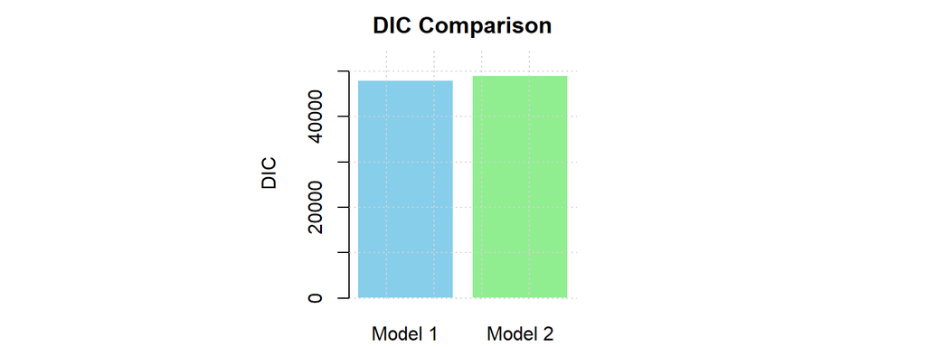